# R Notebook

The following packages have been installed to manipulate our dataset and visualize details about them.

```r
library(readr)
library(dplyr)
library(purrr)
library(ggplot2)
library(stringr)
library(tidyr)
```

The following details we are bringing in are demographic and test score data from the New York City Department of Education as well as survey data for general education schools.

```r
combined <- read_csv('combined.csv')
survey_all <- read_tsv('masterfile11_gened_final.txt')
survey_d75 <- read_tsv('masterfile11_d75_final.txt')
```

Filter survey dataset to only include high school data

```r
survey_filtered <- survey_all %>%
  filter(schooltype == 'High School') %>%
  select(dbn:aca_tot_11)
```

Narrow d75 survey data to only the columns we care to look at

```r
survey_d75_filtered <- survey_d75 %>%
  select(dbn:aca_tot_11)
```

Join both survey data frames and rename key column to match

```r
survey_combined <- survey_filtered %>%
  bind_rows(survey_d75_filtered)
```

```r
survey_combined <- survey_combined %>%
rename(DBN = dbn)
```

Combine the original dataset with the newly combined survey data. Join on DBN

```r
combined_w_survey <- combined %>%
  left_join(survey_combined, by = "DBN")
```

Review correlations between the avg_sat_score and all variables

```r
cor_mat <- combined_w_survey %>%
  select(avg_sat_score, saf_p_11:aca_tot_11) %>%
  cor(use = 'pairwise.complete.obs')

cor_tib <- cor_mat %>%
  as_tibble(rownames = 'variable')
```

Narrow the correlations to only those that appear to be strong

```r
strong_correlations <- cor_tib %>%
  select(variable, avg_sat_score) %>%
  filter(avg_sat_score > 0.25 | avg_sat_score < -0.25)
```

Generate scatter plots to review the correlations

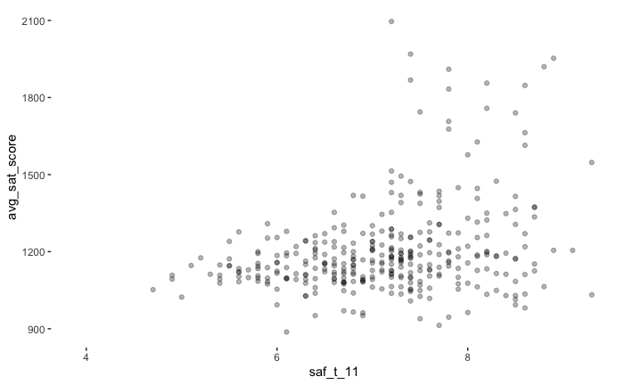

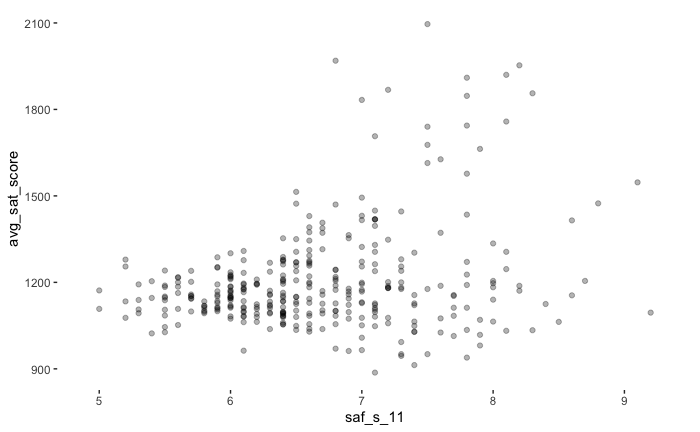

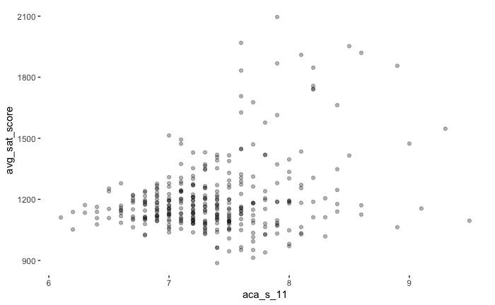

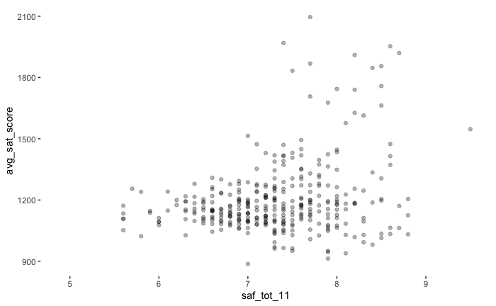

```r
create_scatter <- function(x, y) {
  ggplot(data = combined_w_survey) +
    aes_string(x = x, y = y) +
    geom_point(alpha = 0.3) +
    theme(panel.background = element_rect(fill = 'white'))
}

x_var <- strong_correlations$variable[2:5]
y_var <- 'avg_sat_score'

map2(x_var, y_var, create_scatter)
```

Let’s re-shape to look at survey results from students, parents and teachers

```r
combined_w_survey_gather <- combined_w_survey %>%
  gather(key = 'survey_question', value = score, saf_p_11:aca_tot_11)
```

```r
combined_w_survey_gather <- combined_w_survey_gather %>%
  mutate(response_type = str_sub(survey_question, 4, 6)) %>%
  mutate(question = str_sub(survey_question, 1, 3))
```

Identify the different types of responses based on column naming

```r
combined_w_survey_gather <- combined_w_survey_gather %>%
  mutate(response_type = ifelse(response_type == '_p_', 'parent',
                                ifelse(response_type == '_t_', 'teacher',
                                       ifelse(response_type == '_s_', 'student',
                                              ifelse(response_type == '_to', 'total', 'NA')))))
```

Finally generate a boxplot to review differents between the responder types

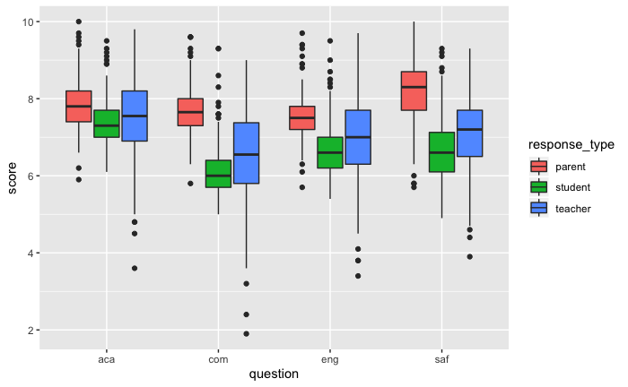

```r
combined_w_survey_gather %>%
  filter(response_type != 'total') %>%
  ggplot() +
  aes(x = question, y = score, fill = response_type) +
  geom_boxplot()
```